# Obtain phylogenetic and interaction distances

```r
#source("../Original_code/functions/tree_functions.R")
#source("../Original_code/functions/phylo_functions.R")
source("AF_functions_tree.R")
library(ape)
library(apTreeshape)
library("vegan")
```

# POSITIVE INTERACTIONS

### Load simulation data

```r
load("./Data/Positive_interactions/list_res_neg_2.Rdata")
```

## Convert spp names from numbers to letters

```r
length(list_anc_dist_letters) == length(list_networks_sppnames_letters)
```

```
[1] TRUE
```

#### Loop for obtaining phylogenetic distances:

Distances can only be calculated from the 3rd matrix in advance, because there is no more than two species until then. So the first two matrix are NULL and we will eliminate them.

We eliminated timestep 1 at the beggining of the code. Eliminating now the 1st (timestep2) and 2nd (timestep3) matrices means that we retain from timestp 4 in advance.

```r
length(list_dist.phylo)
```

```
[1] 174
```

#### Interaction distances

We eliminate the 1st and 2nd matrix (timestep 2 and 3) as we did for the list of phylogenetic distance matrices so that we can compare the lists later.

```r
list_networks_sppnames_letters <- list_networks_sppnames_letters[-c(1,2)]

length(list_networks_sppnames_letters) # 174

# Compute distances

list_dist_chisq<- lapply(list_networks_sppnames_letters, compute_chisq)

# Only from the 4th matrix, so timestep 5
```

PROBLEM HERE - I receive the following waring:

Warning in vegdist(matrix[-which(rowSums(matrix) == 0), ], method = “chisq”, : data have empty species which influence the results in method “chisq”

WARNING: the first and second matrices (timestep 4 and 5) of list_dist_chisq are not valid (too few species to compute chisq distances).So we eliminate them, and therefore also eliminate them from the list of phylogenetic distance matrices, list_dist.phylo, so that both list coincide.

```r
length(list_dist_chisq)
```

```
[1] 172
```

Now I have the phylogenetic distance matrices in list_dist.phylo, and the interaction distances in list_dist_chisq.

Check that both the list of distance matrices for interactions and for phylogeny have the same length:

```r
length(list_dist_chisq[[12]]) == length(list_dist.phylo[[12]])
```

```
[1] FALSE
```

Example to show that phylogenetic distance matrices retain the extinct species together with the present ones.

```r
df.test.phylo <- as.data.frame(list_dist.phylo[[174]])
df.test.chisq <- as.data.frame(list_dist_chisq[[174]])

data_new.phylo <- df.test.phylo[order(names(df.test.phylo)) , order(names(df.test.phylo))]
data_new.chisq <- df.test.chisq[order(names(df.test.chisq)) , order(names(df.test.chisq))]

colnames(data_new.chisq)

colnames(data_new.phylo)
```

[output not shown]

Therefore, I need to 1st order the names of columns and rows of both phylo and interaction distance matrices so that they coincide, and then select only those species present to compare the matrices. The way I will select those species present is by telling the phylo-distance matrix to retain only those species names that the interaction distance matrix has:

## Order column and row spp names

[output not shown]

## For phylogenetic distance matrices, retain only those species present

Species present are those present in the interaction distance matrix.

```r
colnames(list_dist.phylo_df_pres[[100]]) == colnames(list_dist_chisq_df.ord[[100]])
```

```
 [1] TRUE TRUE TRUE TRUE TRUE TRUE TRUE TRUE TRUE TRUE TRUE TRUE TRUE TRUE TRUE TRUE TRUE TRUE TRUE
[20] TRUE TRUE TRUE TRUE TRUE TRUE TRUE TRUE TRUE TRUE TRUE TRUE TRUE TRUE TRUE TRUE TRUE TRUE TRUE
[39] TRUE TRUE TRUE
```

NOW I’M READY TO COMPUTE CORRELATION

# Compute MDS

WARNING: I can’t compute MDS with ~2 spp, so 1st and 2nd matrices can’t be analysed. And I eliminate them from the list (6 and 7 timesteps)

```r
# convert to matrix

list_dist_chisq_mat <- lapply(list_dist_chisq_df.ord, as.matrix)
list_dist.phylo_mat <- lapply(list_dist.phylo_df_pres, as.matrix)


## Eliminate 1st and 2nd matrix - too few spp to compute MDS

list_dist_chisq_mat <- list_dist_chisq_mat[-c(1,2)]
list_dist.phylo_mat <- list_dist.phylo_mat[-c(1,2)]



# compute mds

list_mds.int <- list()
list_mds.phy <- list()


# Compute NMS

for (i in 1:length(list_dist_chisq_mat)) {

list_mds.int[[i]] <- monoMDS(list_dist_chisq_mat[[i]], y = cmdscale(list_dist_chisq_mat[[i]]))
list_mds.phy[[i]] <- monoMDS(list_dist.phylo_mat[[i]], y = cmdscale(list_dist.phylo_mat[[i]]))

}
```

# Compute correlation

already have distance matrices computed (chisq, phylo)

| timesteps | protest_pval | protest_corr | sign | nspp |
| --- | --- | --- | --- | --- |
| 8 | 1.0000000 | 0.9801977 | non.sign | 4 |
| 9 | 0.6666667 | 0.6957974 | non.sign | 5 |
| 10 | 0.4000000 | 0.5732694 | non.sign | 6 |
| 11 | 0.0640000 | 0.6864456 | non.sign | 8 |
| 12 | 0.0660000 | 0.6778870 | non.sign | 7 |
| 13 | 0.1850000 | 0.6531083 | non.sign | 7 |
| 14 | 0.0200000 | 0.7374937 | sign | 9 |
| 15 | 0.0320000 | 0.6297273 | sign | 11 |
| 16 | 0.0050000 | 0.6876623 | sign | 12 |
| 17 | 0.0520000 | 0.5311022 | non.sign | 13 |

[output cut: 160 more lines]

### Plot phylogenetic signal through time

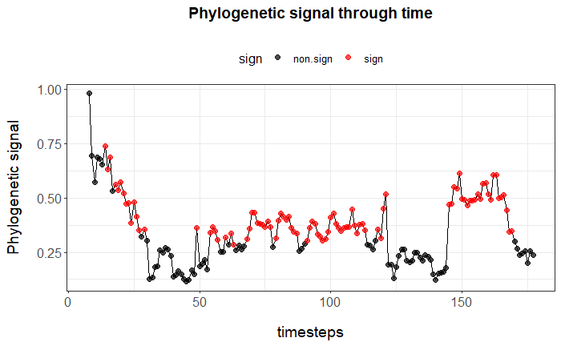

### Plot species richness through time

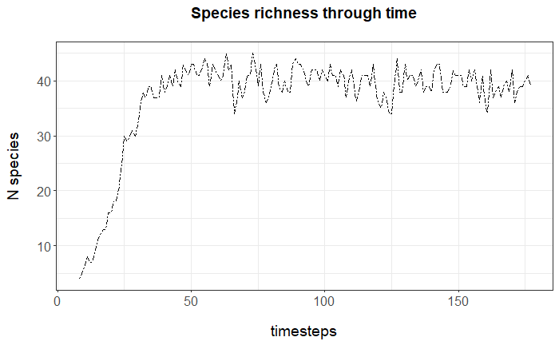

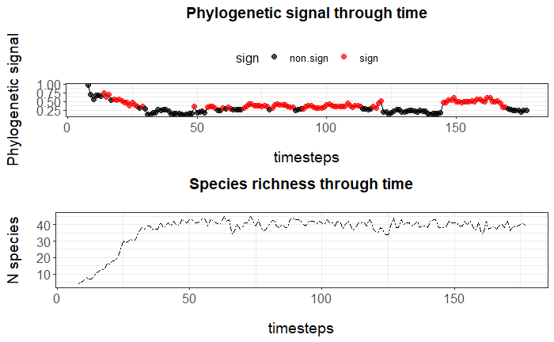

```r
arranged.plots <- grid.arrange(p, p.spp,
             ncol = 1, nrow = 2)

arranged.plots
```

[output not shown]

# NEGATIVE INTERACTIONS

### Load simulation data

```r
load("../Data/Negative_interactions/list_res_neg_2.Rdata")

names(list_res) = c("simulation1", "simulation2")

list_simulation1 <- list_res$simulation1


# List for table ancestry-distances and networks
# The first element of both is NULL, so we eliminated it

list_anc_dist <- list_simulation1$list_anc_dist[-1]
network_list <- list_simulation1$network_list[-1]

length(list_anc_dist) == length(network_list)
```

```
[1] TRUE
```

## Convert spp names from numbers to letters

```r
## Ancestry-distance

list_anc_dist_letters <- lapply(list_anc_dist, change_sppnames_letters_ancdist.table)


## Interactions

#### 1st, set names as numbers (index of columns and rows)

# WARING - Eliminating first timestep

list_networks_sppnames_numbers <- lapply(network_list, set_sppNames_numbers)

#### 2nd, convert numbers to letters

list_networks_sppnames_letters <- lapply(list_networks_sppnames_numbers, convert_sppnames_toletters)



length(list_anc_dist_letters) == length(list_networks_sppnames_letters)
```

```
[1] TRUE
```

#### Loop for obtaining phylogenetic distances:

Distances can only be calculated from the 3rd matrix in advance, because there is no more than two species until then. So the first two matrix are NULL and we will eliminate them.

We eliminated timestep 1 at the beggining of the code. Eliminating now the 1st (timestep2) and 2nd (timestep3) matrices means that we retain from timestp 4 in advance.

```r
length(list_dist.phylo) # 174
```

```
[1] 170
```

#### Interaction distances

```r
list_networks_sppnames_letters <- list_networks_sppnames_letters[-c(1:5)]

length(list_networks_sppnames_letters) # 170

# Compute distances

list_dist_chisq<- lapply(list_networks_sppnames_letters, compute_chisq)

# Only from the 5th matrix, so timestep 7
```

PROBLEM HERE - I receive the following waring:

Warning in vegdist(matrix[-which(rowSums(matrix) == 0), ], method = “chisq”, : data have empty species which influence the results in method “chisq”

```r
length(list_dist.phylo)
```

```
[1] 168
```

Now I have the phylogenetic distance matrices in list_dist.phylo, and the interaction distances in list_dist_chisq.

Check that both the list of distance matrices for interactions and for phylogeny have the same length:

```r
length(list_dist_chisq[[12]]) == length(list_dist.phylo[[12]])
```

```
[1] FALSE
```

Example to show that phylogenetic distance matrices retain the extinct species together with the present ones.

```r
df.test.phylo <- as.data.frame(list_dist.phylo[[174]])
df.test.chisq <- as.data.frame(list_dist_chisq[[174]])

data_new.phylo <- df.test.phylo[order(names(df.test.phylo)) , order(names(df.test.phylo))]
data_new.chisq <- df.test.chisq[order(names(df.test.chisq)) , order(names(df.test.chisq))]

colnames(data_new.chisq)

colnames(data_new.phylo)
```

[output not shown]

Therefore, I need to 1st order the names of columns and rows of both phylo and interaction distance matrices so that they coincide, and then select only those species present to compare the matrices. The way I will select those species present is by telling the phylo-distance matrix to retain only those species names that the interaction distance matrix has:

## Order column and row spp names

```r
list_dist.phylo_df <- lapply(list_dist.phylo, as.data.frame)
list_dist_chisq_df <- lapply(list_dist_chisq, as.data.frame)


list_dist.phylo_df.ord <- lapply(list_dist.phylo_df, order_col.row_names)
list_dist_chisq_df.ord <- lapply(list_dist_chisq_df, order_col.row_names)
```

## For phylogenetic distance matrices, retain only those species present

Species present are those present in the interaction distance matrix.

```r
# Select only spp present for phylogenetic distance matrix

list_dist.phylo_df_pres <- list()

for (i in 1:length(list_dist.phylo_df.ord)) {

  spp_present <- colnames(list_dist_chisq_df.ord[[i]])
  list_dist.phylo_df_pres[[i]] <- list_dist.phylo_df.ord[[i]][spp_present ,spp_present]


}

## Check that now phylo and interaction distance matrices have the same number of spp, same names, and in the same order


colnames(list_dist.phylo_df_pres[[100]]) == colnames(list_dist_chisq_df.ord[[100]])
```

```
 [1] TRUE TRUE TRUE TRUE TRUE TRUE TRUE TRUE TRUE TRUE TRUE TRUE TRUE TRUE TRUE TRUE TRUE TRUE TRUE
[20] TRUE TRUE TRUE TRUE TRUE TRUE TRUE TRUE TRUE TRUE TRUE TRUE TRUE TRUE TRUE TRUE TRUE TRUE TRUE
[39] TRUE TRUE TRUE
```

NOW I’M READY TO COMPUTE CORRELATION

# Compute MDS

```r
# convert to matrix

list_dist_chisq_mat <- lapply(list_dist_chisq_df.ord, as.matrix)
list_dist.phylo_mat <- lapply(list_dist.phylo_df_pres, as.matrix)


## Eliminate until 5th matrix - too few spp to compute MDS

list_dist_chisq_mat <- list_dist_chisq_mat[-c(1:5)]
list_dist.phylo_mat <- list_dist.phylo_mat[-c(1:5)]



# compute mds

list_mds.int <- list()
list_mds.phy <- list()


# Compute NMS

for (i in 1:length(list_dist_chisq_mat)) {

list_mds.int[[i]] <- monoMDS(list_dist_chisq_mat[[i]], y = cmdscale(list_dist_chisq_mat[[i]]))
list_mds.phy[[i]] <- monoMDS(list_dist.phylo_mat[[i]], y = cmdscale(list_dist.phylo_mat[[i]]))

}
```

# Compute correlation

already have distance matrices computed (chisq, phylo)

PROBLEM:

I receive the following waring message when computing the protest() in the loop

‘nperm’ >= set of all permutations: complete enumeration. Set of permutations < ‘minperm’. Generating entire set.

| timesteps | protest_pval | protest_corr | sign |
| --- | --- | --- | --- |
| 14 | 1.0000000 | 0.5527708 | non.sign |
| 15 | 1.0000000 | 0.5960396 | non.sign |
| 16 | 1.0000000 | 0.6215816 | non.sign |
| 17 | 1.0000000 | 0.6378579 | non.sign |
| 18 | 1.0000000 | 0.6490246 | non.sign |
| 19 | 1.0000000 | 0.4793121 | non.sign |
| 20 | 1.0000000 | 0.4841075 | non.sign |
| 21 | 0.5333333 | 0.5880203 | non.sign |
| 22 | 0.7500000 | 0.3991324 | non.sign |
| 23 | 1.0000000 | 0.4053277 | non.sign |

[output cut: 153 more lines]

### Plot phylogenetic signal through time

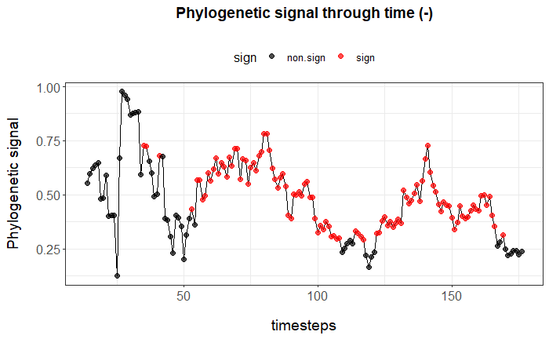

### Plot species richness through time

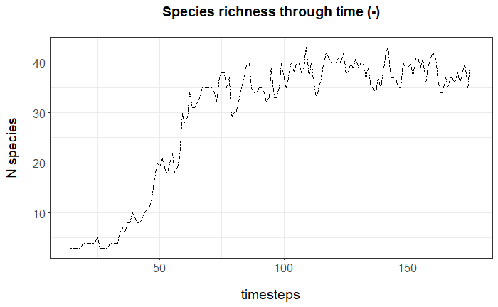

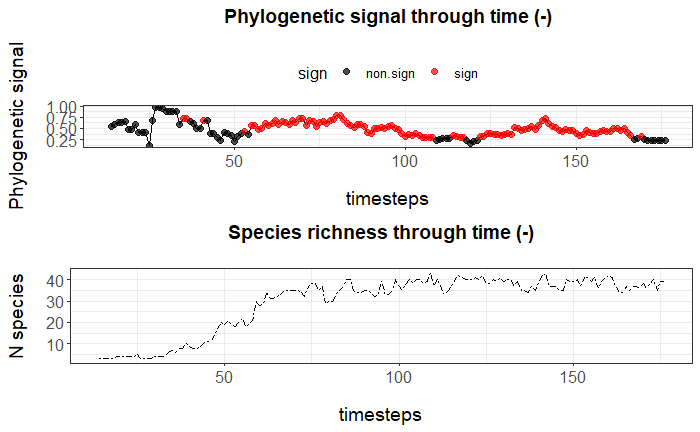